# Lab 4

Aliza Fassler

9/29/2021

I worked with Justin Roch, Joshua Driscoll and Abby Guinan on this lab.

# **Q1 Vector Code**

**(1 pt.) Show the code you used to create your vectors**

```r
norm_17 = rnorm(17, mean = 10.4, sd = 2.4)
norm_30 = rnorm(30, mean = 10.4, sd = 2.4)
norm_300 = rnorm(300, mean = 10.4, sd = 2.4)
norm_3000 = rnorm(3000, mean = 10.4, sd = 2.4)
```

# **Q2 Histogram Code**

**(2 pts.) Include the R code you used to create your figure. Your answer should include code that builds the figure as well as saves it to a file.**

```r
png(filename = here("images","lab_04_hist_01.png"), width = 1500, height = 1600, res = 180, units = "px")
par(mfrow = c(2,2))
hist(norm_17, main = "Norm 17")
hist(norm_30, main = "Norm 30")
hist(norm_300, main = "Norm 300")
hist(norm_3000, main = "Norm 3000")
dev.off()
```

# **Q3 Histogram Figure**

**(4 pts.) Upload your lab_04_hist_01.png file to Moodle. Make sure you double check the image size and resolution requirements.**

# **Q4 Histogram Shapes 1**

# **Q5 Histogram Shapes 2**

**Explain why the shapes of the histograms are different.** The shapes of the historgrams are different because of the sample size and which random values were pulled by rnorm(). For example, for the Norm 17 histogram there is a great deal of variability between the values rnorm() generated because we only asked it to generate 17 values. As we told rnorm() to pull more and more values the frequency of these values accumulates in a way that creates a histogram with a shape approaching the normal distribution.

# **Q6: (1 pt) What are the parameters and their values for the standard Normal distribution?**

The parameters of the normal distribution are mean and standard deviation. For a standard normal distribution the mean value = 0 and the standard deviation = 1.

```r
x = seq(-100,100 , length.out = 1000)
y = dnorm(x, mean = 10.4, sd = 2.4)

svg(filename = here("images","norm_1.svg"), width = 7, height = 8, pointsize = 14)
plot(x, y, main = "Normal PDF with mean = 10.4 and sd =2.4", type = "l", xlim = c(2, 19))
abline(h = 0)
dev.off()
```

# **Q9 Random Data Set**

**(3 pts.) Show the R code you used to create one of the random datasets in your figure.**

```r
n_pts4 = c(1:500)
x_min4 = 1
x_max4 = 400
x4 = dunif(n_pts4, min = x_min4, max = x_max4)
dat4 = data.frame(x = x4, y_observed4 = dnorm(n_pts4))
```

# **Q11 Random Data Model Fit (Q 13-14)**

**(3 pts.) Show the R code you used to create one of the random datasets in your figure.**

```r
set.seed(20)
n_pts = 15
x_min = 1
x_max = 50
x3 = runif(n = n_pts, min = x_min, max = x_max)
dat3 = data.frame(x = x3, y_observed3 = rnorm(n_pts))
```

# **Q13 Random Data Model Residuals (Q 13-14)**

**(2 pts.) Paste the R code you used to create create the columns of predicted values and residuals.**

```r
Y_predicted = line_point_slope(dat3$x, guess_x, guess_y, guess_slope)
dat3$y_predicted = Y_predicted
dat3$resids = dat3$y_predicted - dat3$y_observed
```

# **Q14 Random Data Model Residual Plot**

**(3 pts.) In your report, include the two following figures** **A histogram of the model’s residuals.** **A scatterplot of your model’s predicted values (on the x-axis) and residuals (on the y-axis).**

##residual plots

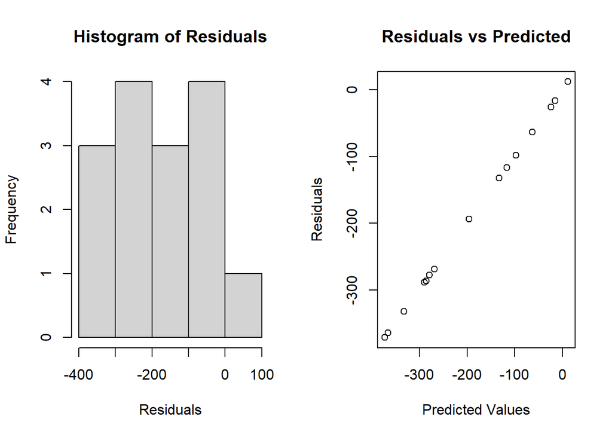

```r
par(mfrow =c(1,2))
hist(dat3$resids, main = "Histogram of Residuals", xlab = "Residuals")
plot(dat3$resids ~ dat3$y_predicted, main = "Residuals vs Predicted", ylab = "Residuals", xlab = "Predicted Values")
```